# PosteriorEta

Euphy Wu

2024-10-04

In this document, I focus on three key steps, each demonstrated with simple code:

1. Draw samples from the posterior distribution of $\eta$
2. Plot a histogram of the posterior draws of $\eta$
3. Plot a histogram of the $\Gamma$ estimates using the drawn $\eta$ values, fitted with a mixed linear regression model

As an example, I use a previously fitted model with 3 samples, each exhibiting changes in cell type proportions between time points. The dataset consists of a total of 5 distinct cell types.

## Draw From Posterior Distribution of Eta

The posterior distribution $\eta_{l,k} \sim N(\lambda_{l,k}, nu^2_{l,k})$, where $l$ is cell and $k$ is topic/cell type. Draw $100$ replicates for each cell from the posterior distributions. `model` is the previously run scSTMseq model object.

```r
lambda <- model$eta # mean of eta
nu <- model$nu # variance of eta
nsims <- 100 # number of posterior draw

out <- vector("list", nrow(lambda))
# for each cell ,draw from the posterior distribution
for (i in seq_len(nrow(lambda))) {
  sigma <- nu[[i]]
  lambda_i <- lambda[i,]
  out[[i]] <- mvrnorm(nsims, mu = lambda_i, Sigma = sigma) # draw from the posterior distribution of eta
}
names(out) <- rownames(lambda)
```

## Histogram of the posterior draw of Eta

We first look at the histogram of the distribution of posterior draw of $\eta$ for one single sample, for topic 1 at time 1 only. That gives us 497 cells, each with 100 replicates of eta.

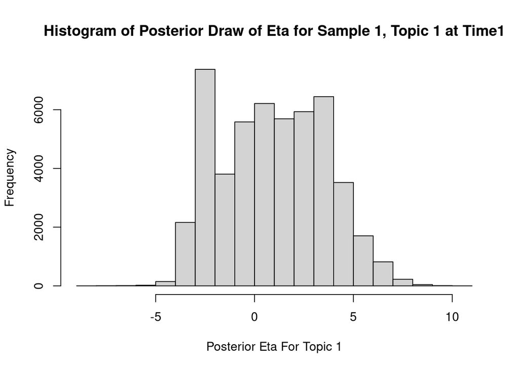

```r
# first extract all cells that belongs to sample 1 at time 1
metaset <- colData(model$settings$sce) %>%
  as.data.frame() %>%
  dplyr::filter(Sample == "Sample1" & Time == "Time1")

# matching the above cells with the posterior draw in the previous step
PosteriorEta <- out[metaset$Cell]
PosteriorEta <- do.call(rbind, PosteriorEta)
# plotting only topic 1
hist(PosteriorEta[,1], main = "Histogram of Posterior Draw of Eta for Sample 1, Topic 1 at Time1", xlab = "Posterior Eta For Topic 1")
```

Then we look at a violin plot for the same posterior $\eta$ distribution, across all three samples, at both time points, for topic 1 only. The estimated $\eta$ from the model was mapped in red. The underlying simulation has decreasing cell type 1 between time points for sample 2 and 3, but increasing cell type 1 for sample 1.

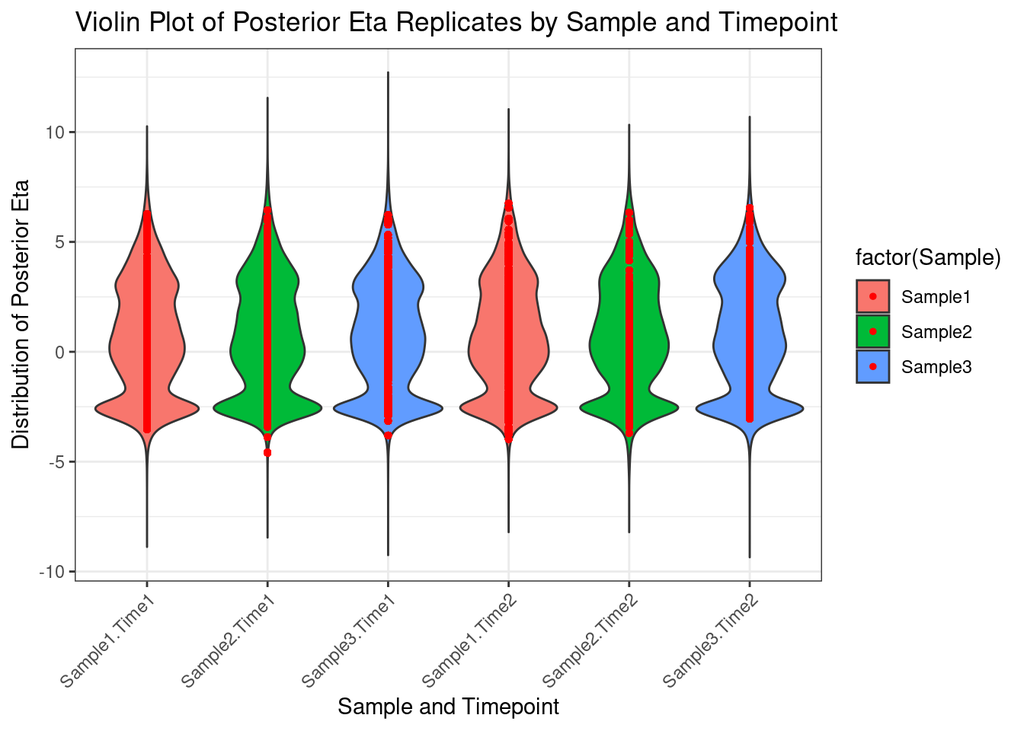

```r
estimateEta <- model$eta[,1]
PosteriorEta_G1 <- lapply(out, function(x) x[, 1])
PosteriorEta_G1 <- data.frame(Cell = names(PosteriorEta_G1), Value = unlist(PosteriorEta_G1))
metadata <- colData(model$settings$sce) %>%
  as.data.frame() %>%
  select(Cell, Time, Sample)
metadata$estimateEta <- estimateEta
# align posterior replicates with their Sample and Timepoint information
plot_data <- PosteriorEta_G1 %>% left_join(metadata, by = "Cell")

ggplot(plot_data, aes(x = interaction(Sample, Time), y = Value, fill = factor(Sample))) +
  geom_violin(trim = FALSE) +
  theme_bw() +
  geom_point(aes(y = estimateEta), color = "red", size = 1) +
  labs(x = "Sample and Timepoint", y = "Distribution of Posterior Eta",
       title = "Violin Plot of Posterior Eta Replicates by Sample and Timepoint") +
  theme(axis.text.x = element_text(angle = 45, hjust = 1))
```

## Histogram of the estimation of Gamma with sampled Eta

`SimEta` contains posterior draw of all the cells in the dataset, and we have `nsims = 100` such draw.

One such draw looks like the following

|  | Topic1 | Topic2 | Topic3 | Topic4 |
| --- | --- | --- | --- | --- |
| Cell1 | 1.2 | -0.3 | 0.5 | 5.1 |
| Cell2 | 3.4 | 1.5 | -6.2 | 1.3 |
| … | … | … | … | … |
| CellN | -0.5 | 0.2 | 3.1 | -9.2 |

For each complete posterior draw, we can fit a mixed linear regression for a given topic,. For example, fitting a mixed linear model for topic 1, the response variable is the first column in the above matrix. Repeat this step for all 100 replicates.

```r
lmer.formula = ~Time + (1|Sample) # mixed linear model formula
for(i in 1:length(SimEta)){ # model fitting for each posterior dataset
  Y_all <- SimEta[[i]]
  res <- data.frame()
  for (k in seq_len(ncol(Y_all))) { # one mixed regression for each topic
    lm.model.temp <- lme4::lmer(lmer.formula, data = X)
    temp.res <- summary(lm.model.temp)$coefficients[,"Estimate"] # extract the estimation of gamma
    res <- rbind(res, temp.res)
  }
  gamma[[i]] <-  res
}
```

From the above analysis, we get 100 estimated $\Gamma$ for each topic, in addition to the one estimated $\Gamma$ from the model. We can pthen lot the distribution of estimated $\Gamma$ fitted using mixed linear model with the posterior eta replicates as response variables, where the estimated $\Gamma$ from the model was highlighted in red.

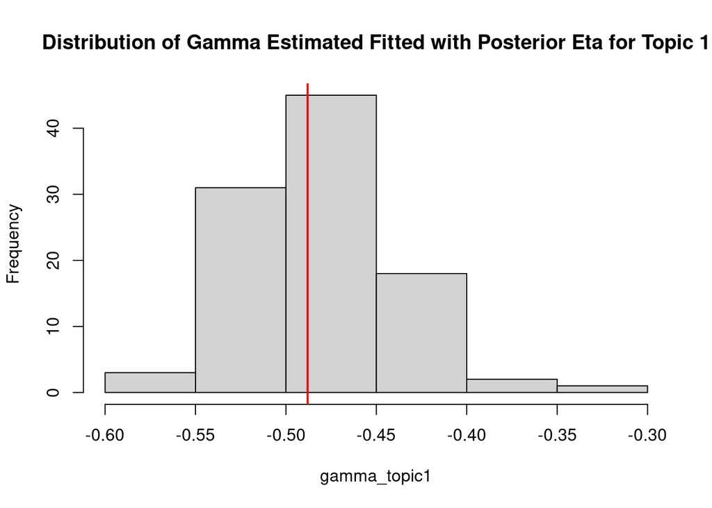

```r
gamma_topic1 <- lapply(gamma, function(x) x["topic_1", "TimeTime2"])
gamma_topic1 <- do.call(c, gamma_topic1)
estimated_gamma <- model$mu$gamma["TimeTime2", 1]
hist(gamma_topic1, main = "Distribution of Gamma Estimated Fitted with Posterior Eta for Topic 1")
abline(v = estimated_gamma, col = "red", lwd = 2)
```